# Lab 2

Arlena Wang

9/19/2021

## R Markdown

```r
library(classdata)
data(choco)
str(choco)
```

```
## Classes 'tbl_df', 'tbl' and 'data.frame':    2452 obs. of  13 variables:
##  $ REF               : num  2454 2458 2454 2542 2546 ...
##  $ Company           : chr  "5150" "5150" "5150" "5150" ...
##  $ Location          : chr  "U.S.A." "U.S.A." "U.S.A." "U.S.A." ...
##  $ ReviewDate        : num  2019 2019 2019 2021 2021 ...
##  $ CountryBeanOrigin : chr  "Tanzania" "Dominican Republic" "Madagascar" "Fiji" ...
##  $ SpecificBeanOrigin: chr  "Kokoa Kamili, batch 1" "Zorzal, batch 1" "Bejofo Estate, batch 1" "Matasawalevu, batch 1" ...
##  $ Ingredients       : chr  "3- B,S,C" "3- B,S,C" "3- B,S,C" "3- B,S,C" ...
##  $ Characteristics1  : chr  "rich cocoa" "cocoa" "cocoa" "chewy" ...
##  $ Characteristics2  : chr  "fatty" "vegetal" "blackberry" "off" ...
##  $ Characteristics3  : chr  "bready" "savory" "full body" "rubbery" ...
##  $ Characteristics4  : chr  NA NA NA NA ...
##  $ Rating            : num  3.25 3.5 3.75 3 3 3.25 3.5 3.5 3.75 2.75 ...
##  $ CocoaPercent      : num  76 76 76 68 72 80 68 70 63 70 ...
```

#Searching for the Best Chocolates

1.) How are the cocoa percent distributed? Create both a histogram and a boxplot and describe them. Don’t forget to mention outliers, if there are any.

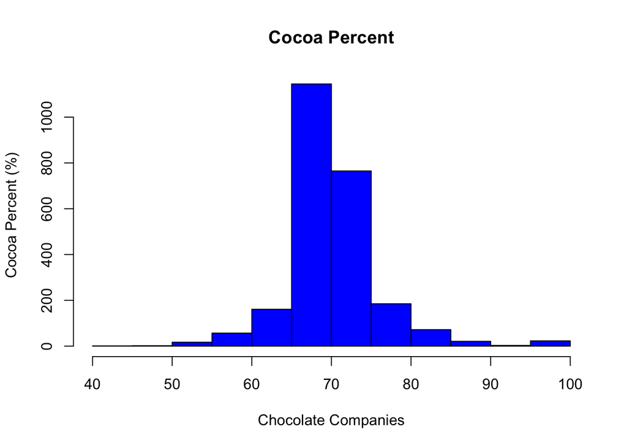

```r
hist(choco$CocoaPercent, main = "Cocoa Percent", xlab = "Chocolate Companies", ylab = "Cocoa Percent (%)", col = "blue")
```

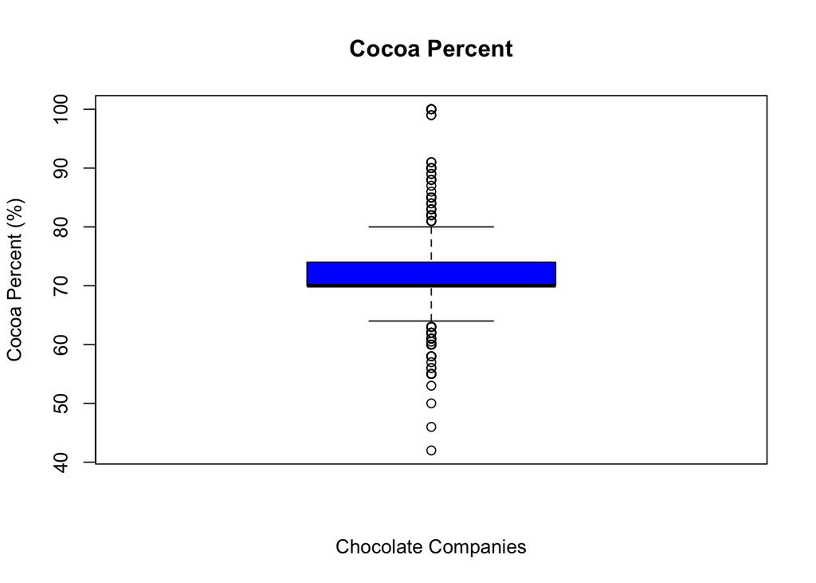

```r
boxplot(choco$CocoaPercent, main = "Cocoa Percent", xlab = "Chocolate Companies", ylab = "Cocoa Percent (%)", col = "blue")
```

```r
summary(choco$CocoaPercent)
```

```
##    Min. 1st Qu.  Median    Mean 3rd Qu.    Max.
##   42.00   70.00   70.00   71.65   74.00  100.00
```

2.) How does the number of ratings depend on the country of bean origin? Draw a bar chart of the number of ratings by bean origin. [Hint: If your graph is too dense and the labels are not legible, show fewer bean origins.]

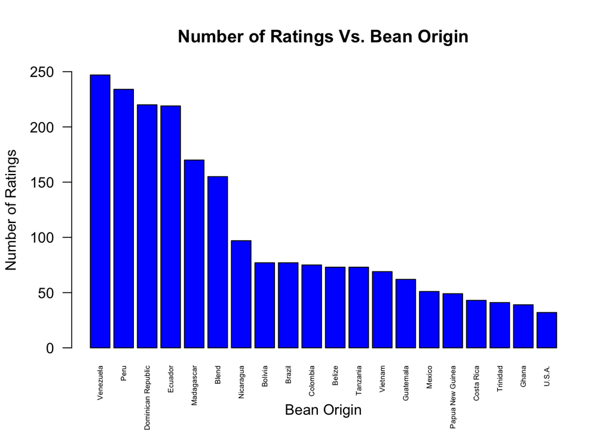

```r
Country <-sort(table(choco$CountryBeanOrigin), decreasing = TRUE)
beanorigin <- head(Country, 20)
barplot(beanorigin, las = 2, cex.names = 0.5, ylim = c(0, 250), main = "Number of Ratings Vs. Bean Origin", xlab = "Bean Origin", ylab = "Number of Ratings", col = "blue")
```

The number of ratings seem to be highest in Venezuela. Some other countries that have high ratings are in Peru, Dominican Republic, and Ecuador. Cocoa beans originate and are grown in the Amazon which include the counties Venezuela, Peru, Ecuador, etc. These countries get more cocoa beans which leads them to get more ratings. Therefore, the number of ratings do seem to depend on the country of bean origin.

3.) Do ratings depend on the cacao percentage of a chocolate bar? Create both numerical and graphical summaries, and explain. [Hint: Think about why the scatterplot is not a very good choice for visualization here.]

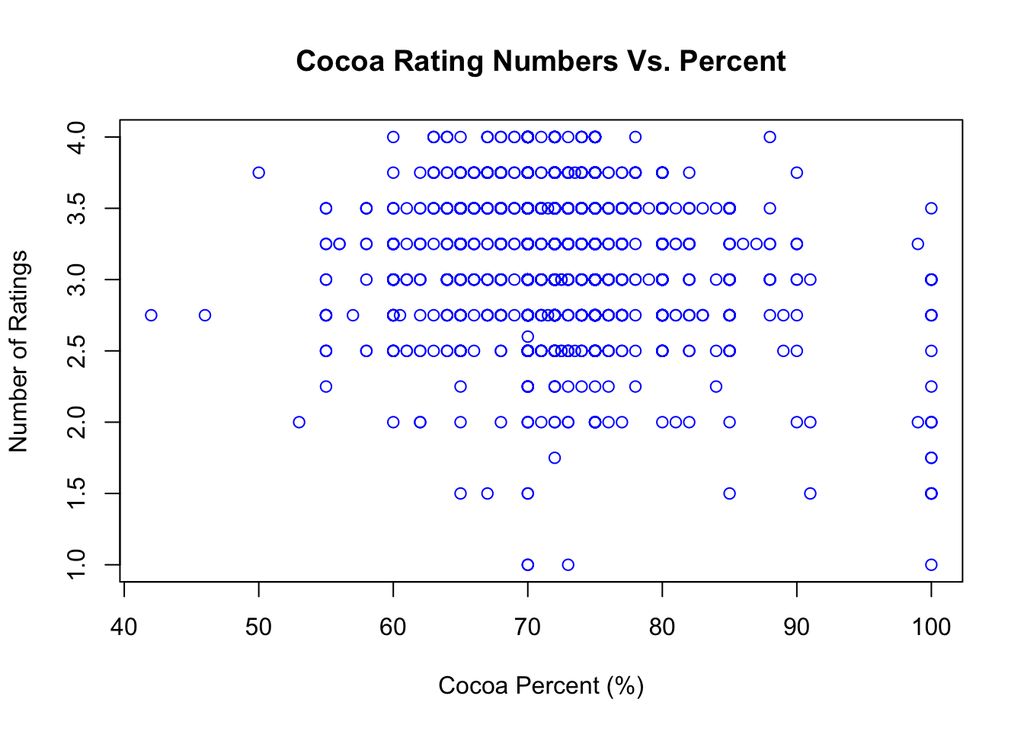

```r
plot(choco$CocoaPercent, choco$Rating, main = "Cocoa Rating Numbers Vs. Percent", xlab = "Cocoa Percent (%)", ylab = "Number of Ratings", col = "blue")
```

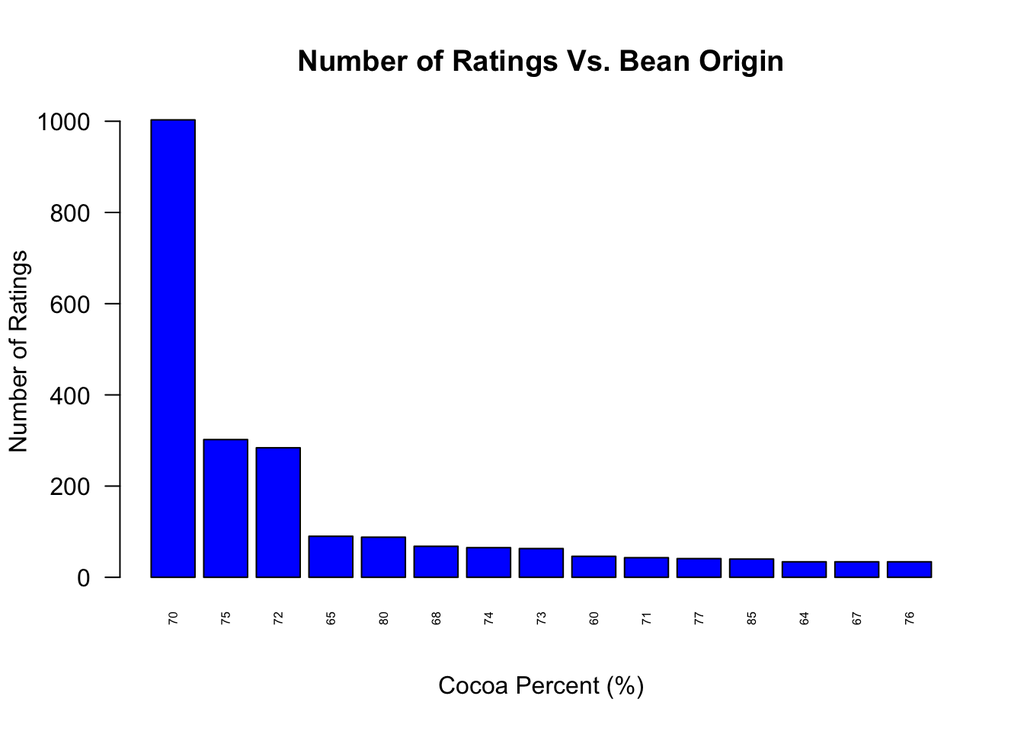

```r
Cocoa <-sort(table(choco$CocoaPercent), decreasing = TRUE)
cocoapercent <- head(Cocoa, 15)
barplot(cocoapercent, las = 2, cex.names = 0.5, main = "Number of Ratings Vs. Bean Origin", xlab = "Cocoa Percent (%)", ylab = "Number of Ratings", col = "blue")
```

```r
summary(choco$Rating)
```

```
##    Min. 1st Qu.  Median    Mean 3rd Qu.    Max.
##   1.000   3.000   3.250   3.192   3.500   4.000
```

```r
summary(choco$CocoaPercent)
```

```
##    Min. 1st Qu.  Median    Mean 3rd Qu.    Max.
##   42.00   70.00   70.00   71.65   74.00  100.00
```

There is an abnormally high number of ratings (~1000) in 70% of cocoa in a chocolate bar. Some values near 70% like 75% or 72% are also somewhat higher. Other percentages of cocoa do not have very high numbers of ratings. In addition, the center (median) of the Cocoa Percent is at 70% as well. Although a scatterplot was graphed, it is not a very good choice for visualization because it is very condensed. There are many values that happen to be around the same value and overlap. Thus, the better choice is to use a bar chart because you can more easily see the relationship between Cocoa Ratings and Percent. In addition, from the bar chart, there is no specific pattern, so there is not really a strong relationship between number of ratings and cocoa percent, which is another reason why the scatterplot is not a good representation of the data.

4.) How do different bean origins compare in terms of the flavor of chocolates? Are beans from some places better than the other? Create both numerical and graphical summaries, and explain.

```r
library(tidyverse)
flavor <- table(choco$Characteristics1)
length(flavor)
```

```
## [1] 499
```

```r
summary(as.numeric(flavor))
```

```
##    Min. 1st Qu.  Median    Mean 3rd Qu.    Max.
##   1.000   1.000   1.000   4.914   3.000 162.000
```

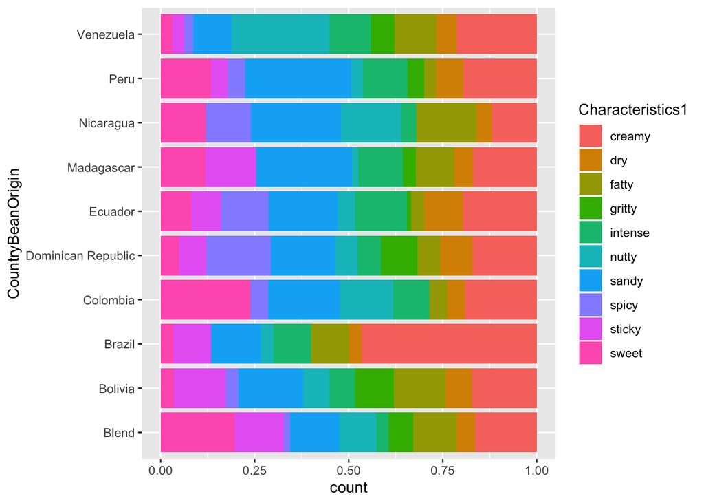

```r
flavor_filtered <- flavor[flavor > 50]
choco_filtered <- filter(choco, Characteristics1 %in% names(flavor_filtered))
country_filtered <- table(choco$CountryBeanOrigin) %>%
  sort(decreasing = TRUE) %>%
  head(10)
choco %>%
  filter(Characteristics1 %in% names(flavor_filtered)) %>% # filter flavor
  filter(CountryBeanOrigin %in% names(country_filtered)) %>% # filter country
  ggplot() +
  geom_bar(aes(x = CountryBeanOrigin, fill = Characteristics1), position = 'fill') + coord_flip()
```

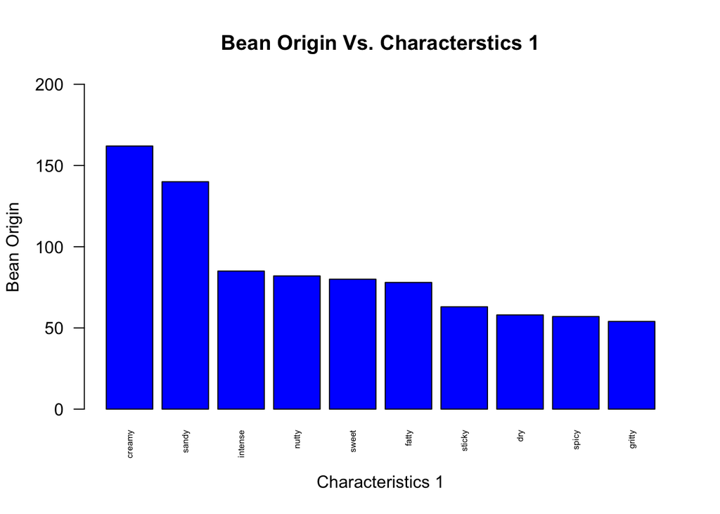

```r
Characterstic1 <- sort(table(choco$Characteristics1), decreasing = TRUE)
Group1 <- head(Characterstic1, 10)
barplot(Group1, las = 2, cex.names = 0.5, ylim = c(0,200), main = "Bean Origin Vs. Characterstics 1", xlab = "Characteristics 1", ylab = "Bean Origin", col = "blue")
```

```r
head(tapply(choco$Rating, choco$CountryBeanOrigin, summary), n =5)
```

```
## $Australia
##    Min. 1st Qu.  Median    Mean 3rd Qu.    Max.
##    2.75    3.00    3.25    3.25    3.50    3.75
##
## $Belize
##    Min. 1st Qu.  Median    Mean 3rd Qu.    Max.
##   2.500   3.000   3.250   3.236   3.500   4.000
##
## $Blend
##    Min. 1st Qu.  Median    Mean 3rd Qu.    Max.
##   1.000   2.750   3.000   3.037   3.500   4.000
##
## $Bolivia
##    Min. 1st Qu.  Median    Mean 3rd Qu.    Max.
##   2.000   3.000   3.250   3.175   3.500   4.000
##
## $Brazil
##    Min. 1st Qu.  Median    Mean 3rd Qu.    Max.
##   1.750   3.000   3.250   3.263   3.500   4.000
```

5.) If you work on this lab by yourself, brainstorm two analyses you would like to perform. If you work with a teammate, brainstorm at least three analyses with your teammate. Describe in plain language what comparisons are you making. Create suitable numerical and graphical summaries for your analyses. Describe the results.

- Characteristics1 (flavor) and Ratings. I am investigating whether these flavor results affect the ratings.

```r
library(tidyverse)
flavor <- table(choco$Characteristics1)
length(flavor)
```

```
## [1] 499
```

```r
summary(as.numeric(flavor))
```

```
##    Min. 1st Qu.  Median    Mean 3rd Qu.    Max.
##   1.000   1.000   1.000   4.914   3.000 162.000
```

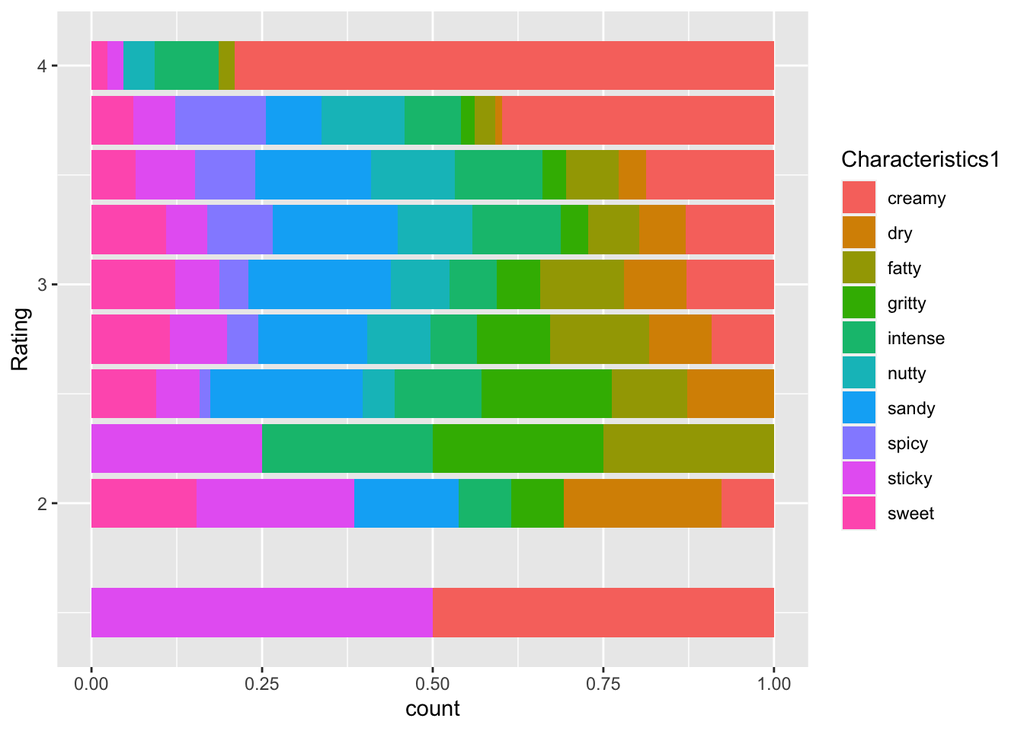

```r
flavor_filtered <- flavor[flavor > 50]
choco_filtered <- filter(choco, Characteristics1 %in% names(flavor_filtered))
rating_filtered <- table(choco$Rating) %>%
  sort(decreasing = TRUE) %>%
  head(10)
choco %>%
  filter(Characteristics1 %in% names(flavor_filtered)) %>% # filter flavor
  filter(Rating %in% names(rating_filtered)) %>% # filter country
  ggplot() +
  geom_bar(aes(x = Rating, fill = Characteristics1), position = 'fill') + coord_flip()
```

```r
head(tapply(choco$Rating, choco$Characteristics1, summary), n =5)
```

```
## $accesible
##    Min. 1st Qu.  Median    Mean 3rd Qu.    Max.
##     3.5     3.5     3.5     3.5     3.5     3.5
##
## $accessible
##    Min. 1st Qu.  Median    Mean 3rd Qu.    Max.
##       3       3       3       3       3       3
##
## $acidic
##    Min. 1st Qu.  Median    Mean 3rd Qu.    Max.
##   1.500   2.500   3.000   2.722   3.250   3.500
##
## $`alluring aroma`
##    Min. 1st Qu.  Median    Mean 3rd Qu.    Max.
##     3.5     3.5     3.5     3.5     3.5     3.5
##
## $aluminum
##    Min. 1st Qu.  Median    Mean 3rd Qu.    Max.
##       3       3       3       3       3       3
```

According to the chart, it seems that the majority of the highest ratings has a creamy flavor. The majority of the lowest rating has a sticky or creamy flavor. All other ratings seem to have a pretty even distribution of different flavor characteristics. It seems that the ratings are not too much affected by the flavor characteristics of the chocolate except for the highest and lowest ratings. I believe only the highest and lowest ratings are only affected by the flavor characteristics. There also is no specific pattern that can visually be seen by the values of the ratings of each flavor characteristic, therefore, there isn’t much dependency of rating on flavor characteristic.

- Location and Ratings. I am investigating which locations have higher number of ratings.

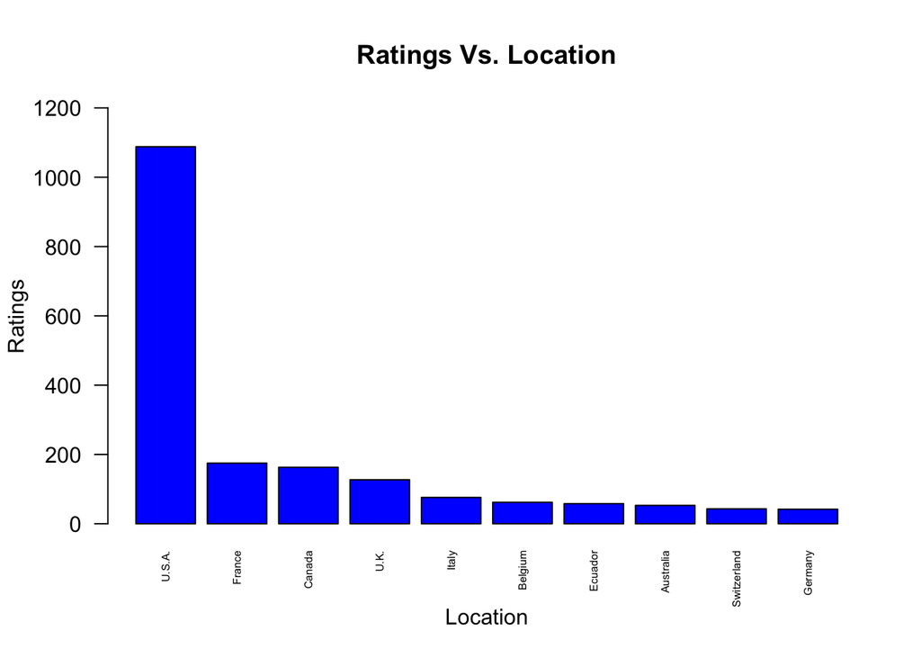

```r
Location <- sort(table(choco$Location), decreasing = TRUE)
Locations <- head(Location, 10)
barplot(Locations, las = 2, cex.names = 0.5, ylim = c(0,1200), main = "Ratings Vs. Location", xlab = "Location", ylab = "Ratings", col = "blue")
```

```r
library(tidyverse)
location <- table(choco$Location)
length(location)
```

```
## [1] 67
```

```r
summary(as.numeric(location))
```

```
##    Min. 1st Qu.  Median    Mean 3rd Qu.    Max.
##     1.0     3.5     9.0    36.6    26.0  1088.0
```

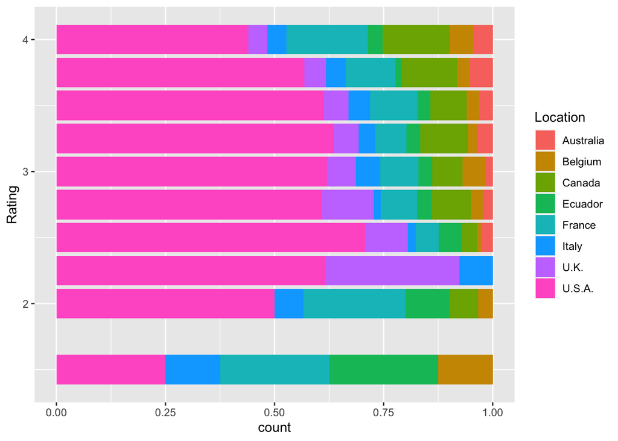

```r
location_filtered <- location[location > 50]
locations_filtered <- filter(choco, Location %in% names(location_filtered))
rating_filtered <- table(choco$Rating) %>%
  sort(decreasing = TRUE) %>%
  head(10)
choco %>%
  filter(Location %in% names(location_filtered)) %>% # filter flavor
  filter(Rating %in% names(rating_filtered)) %>% # filter country
  ggplot() +
  geom_bar(aes(x = Rating, fill = Location), position = 'fill') + coord_flip()
```

```r
head(tapply(choco$Rating, choco$Location, summary), n =5)
```

```
## $Amsterdam
##    Min. 1st Qu.  Median    Mean 3rd Qu.    Max.
##   3.000   3.188   3.250   3.312   3.500   3.750
##
## $Argentina
##    Min. 1st Qu.  Median    Mean 3rd Qu.    Max.
##   2.750   3.250   3.500   3.306   3.500   3.750
##
## $Australia
##    Min. 1st Qu.  Median    Mean 3rd Qu.    Max.
##   2.500   3.000   3.500   3.358   3.750   4.000
##
## $Austria
##    Min. 1st Qu.  Median    Mean 3rd Qu.    Max.
##   2.750   3.000   3.250   3.258   3.500   3.750
##
## $Belgium
##    Min. 1st Qu.  Median    Mean 3rd Qu.    Max.
##   1.000   3.000   3.000   3.097   3.500   4.000
```